# Cluster Analysis

Daniel Ebbert

14.03.2019

## Load the data

First the original data is loaded, merged and cleaned.

```r
# Merge and clean the datasets
source(paste(getwd(), "/R/01_merge-datasets.R", sep = ""))
```

## Average age and gender distribution

The average age in the full data set is: 22.32 The standard deviation in the full data set is: 6.38 The gender distribution in the full data set is as follows:

```r
kable(gender_distribution)
```

| Gender | Freq |
| --- | --- |
| no answer | 0.0244 |
| male | 0.4292 |
| female | 0.5464 |

## Distance matrix

Because the variables that are supposed to be part of the cluster analysis are not all continuous a different distance measure is needed. The used distance measure for this case is Gower distance (Gower 1971). In order to be able to run a cluster analysis with a different distance measure one has to create a distance matrix using this distance matrix. Therefore, the next step is to create a distance matrix using Gower distance.

```r
# Create the distance matrix
source(paste(getwd(), "/R/02_gower-distance.R", sep = ""))

# Show a summary of the distance matrix
summary(gower_dist)
```

```
## 522753 dissimilarities, summarized :
##    Min. 1st Qu.  Median    Mean 3rd Qu.    Max.
##  0.0000  0.1889  0.2833  0.2939  0.4000  0.8889
## Metric :  mixed ;  Types = I, N, N, I, I, N
## Number of objects : 1023
```

## Number of clusters

To determine the number of clusters a cluster analysis using PAM has been done with k ranging from 2 till 10. For each k the silhouette coefficient (Rousseeuw 1987) is calculated and the results plotted in the so called silhouette plot.

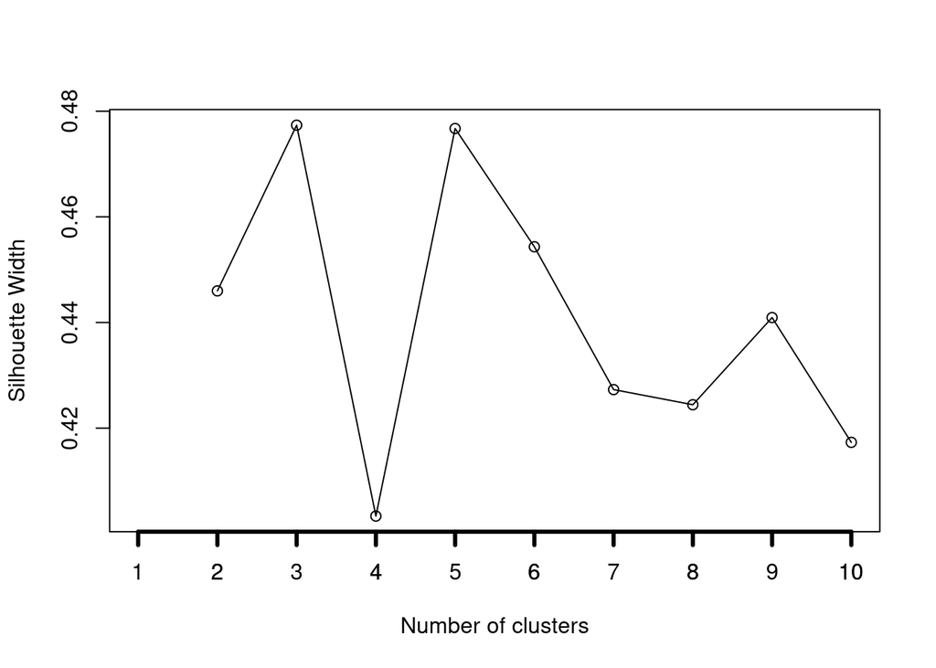

```r
# Run the multiple cluster analysis for the silhouette plot
source(paste(getwd(), "/R/03_silhouette-plot.R", sep = ""))
```

```r
kable(sil_width_df)
```

| Number of clusters | Silhouette Width |
| --- | --- |
| 1 | NA |
| 2 | 0.45 |
| 3 | 0.48 |
| 4 | 0.40 |
| 5 | 0.48 |
| 6 | 0.45 |
| 7 | 0.43 |
| 8 | 0.42 |
| 9 | 0.44 |
| 10 | 0.42 |

The silhouette coefficient is highest at k = 3 and k = 5. The k = 5 clusters solution is more meaningful. Therefore, 5 clusters are extracted.

```r
# Set the number of clusters
n_clusters <- 5
```

## Cluster analysis

Next the cluster analysis is run, the used method is Partitioning Around Medoids (Kaufman and Rousseeuw 1990).

```r
# Run the cluster analysis using PAM
source(paste(getwd(), "/R/04_pam.R", sep = ""))
```

## Aggregate clustering variables

For the following analysis and interpretation the order of the clusters is quite confusing. Therefore the order of the clusters is changed to a meaningful order.

```r
# Run the cluster analysis using PAM
source(paste(getwd(), "/R/05_change_cluster_order.R", sep = ""))
```

In this step the data that went into the cluster analysis is aggregated by cluster and shown in a table:

```r
# Aggregate the data for each cluster
source(paste(getwd(), "/R/06_aggregate.R", sep = ""))

# Show the data for each cluster in a table
kable(cluster_results, row.names = FALSE)
```

| Variable | Cluster 1 | Cluster 2 | Cluster 3 | Cluster 4 | Cluster 5 |
| --- | --- | --- | --- | --- | --- |
| How many of the lecture recordings, of the lecture you attended, did you watch? | Mean=3.438 (SD=0.916) | Mean=2.112 (SD=1.082) | Mean=2.676 (SD=1.033) | Mean=1.727 (SD=0.909) | Mean=3.632 (SD=0.668) |
| Did you watch some lecture recordings multiple times? | Yes (97.9%) | No (95.9%) | Yes (98.1%) | No (97.5%) | No (100%) |
| How did you use the lecture recordings? | I usually watched the lecture recordings completely. (99.7%) | I usually watched the lecture recordings completely. (100%) | I usually only watch parts of a lecture recording. (96.3%) | I usually only watch parts of a lecture recording. (98.1%) | I usually watched the lecture recordings completely. (99.4%) |
| How many lectures did you not attend because you could expect to be able to watch the lecture recording? | Mean=2.276 (SD=1.512) | Mean=1.509 (SD=0.664) | Mean=1.874 (SD=1.37) | Mean=1.555 (SD=1.051) | Mean=4.018 (SD=0.961) |
| How did you use the lecture recordings? | Mean=1.159 (SD=0.376) | Mean=1.041 (SD=0.214) | Mean=1.142 (SD=0.376) | Mean=1.114 (SD=0.338) | Mean=1.088 (SD=0.284) |
| Where did you usually watch the lecture recordings? | at home (93.5%) | at home (90.9%) | at home (91.6%) | at home (91.8%) | at home (90.1%) |
| Size | 291 | 296 | 107 | 158 | 171 |

## Test for significant differences on each cluster variable

This step tests for a significant difference on each cluster variable. For continious variables the Kruskal-Wallis Rank Sum Test (Kruskal and Wallis 1952) is used and for categorical variables Pearson’s Chi-squared Test for Count Data (Pearson 1900) with Monte Carlo simulation (Hope 1968) is used. The number of repetitions used in the Monte Carlo simulation is 8000 (Mundform et al. 2011).

```r
# Test for significant difference on each cluster variable
source(paste(getwd(), "/R/07_tests_for_difference_in_cluster_variables.R", sep = ""))

# Show the test result for each variable in a table
kable(difference_tests_summary_cluster_variables)
```

| Variable | Test | p.value | Significant |
| --- | --- | --- | --- |
| How many of the lecture recordings, of the lecture you attended, did you watch? | Kruskal-Wallis rank sum test | 0.000000 | TRUE |
| Did you watch some lecture recordings multiple times? | Pearson’s Chi-squared test with simulated p-value (based on 8000 replicates) | 0.000125 | TRUE |
| How did you use the lecture recordings? | Pearson’s Chi-squared test with simulated p-value (based on 8000 replicates) | 0.000125 | TRUE |
| How many lectures did you not attend because you could expect to be able to watch the lecture recording? | Kruskal-Wallis rank sum test | 0.000000 | TRUE |
| How did you use the lecture recordings? | Kruskal-Wallis rank sum test | 0.000066 | TRUE |
| Where did you usually watch the lecture recordings? | Pearson’s Chi-squared test with simulated p-value (based on 8000 replicates) | 0.437945 | FALSE |

For the variables where the difference between the clusters is significant a post-hoc test is conducted. For continious variables the post-hoc test used is the Conover-Iman test (Conover and Iman 1979) and for the categorical variables the residuals from the Pearson’s Chi-squared Test for Count Data with Monte Carlo simulation is used (Beasley and Schumacker 1995). Based on the residuals a p value is calculated. For this proces a self written R package called chisq.posthoc.test is used. In both cases the p values are adjusted using the Bonferroni method (Dunn 1961).

**Conover-Iman test for: How many of the lecture recordings, of the lecture you attended, did you watch?**

```r
# Conover-Iman test to determine which of the clusters differ.
conover.test(cluster_data$Q5_1,
             cluster_data$cluster,
             method = "bonferroni",
             altp = TRUE)
```

```
##   Kruskal-Wallis rank sum test
##
## data: x and group
## Kruskal-Wallis chi-squared = 386.2604, df = 4, p-value = 0
##
##
##                            Comparison of x by group
##                                  (Bonferroni)
## Col Mean-|
## Row Mean |          1          2          3          4
## ---------+--------------------------------------------
##        2 |   17.07625
##          |    0.0000*
##        3 |   7.448129  -4.984253
##          |    0.0000*    0.0000*
##        4 |   18.24608   4.078864   7.683269
##          |    0.0000*    0.0005*    0.0000*
##        5 |  -2.013352  -16.74178  -8.416151  -18.14575
##          |     0.4434    0.0000*    0.0000*    0.0000*
##
## alpha = 0.05
## Reject Ho if p <= alpha
```

**Pearson’s Chi-squared Test for Count Data with Monte Carlo simulation residuals analysis for: Did you watch some lecture recordings multiple times?**

```r
# Run a posthoc test based on the residuals to determine which clusters differ
kable(chisq.posthoc.test(
  table(cluster_data$Q5_2, cluster_data$cluster),
  method = "bonferroni",
  simulate.p.value = TRUE,
  B = 8000
))
```

| Dimension | Value | 1 | 2 | 3 | 4 | 5 |
| --- | --- | --- | --- | --- | --- | --- |
| no answer | Residuals | -0.3786324 | 2.303005 | -0.3444136 | 0.1676232 | -2.220951 |
| no answer | p values | 1.0000000 | 0.319178 | 1.0000000 | 1.0000000 | 0.395314 |
| No | Residuals | -24.4589183 | 15.141379 | -13.2583795 | 10.5656093 | 11.814289 |
| No | p values | 0.0000000 | 0.000000 | 0.0000000 | 0.0000000 | 0.000000 |
| Yes | Residuals | 24.8359163 | -16.019425 | 13.5061086 | -10.7297290 | -11.247255 |
| Yes | p values | 0.0000000 | 0.000000 | 0.0000000 | 0.0000000 | 0.000000 |

**Pearson’s Chi-squared Test for Count Data with Monte Carlo simulation residuals analysis for: How did you use the lecture recordings?**

```r
# Run a posthoc test based on the residuals to determine which clusters differ
kable(chisq.posthoc.test(
  table(cluster_data$Q5_4, cluster_data$cluster),
  method = "bonferroni",
  simulate.p.value = TRUE,
  B = 8000
))
```

| Dimension | Value | 1 | 2 | 3 | 4 | 5 |
| --- | --- | --- | --- | --- | --- | --- |
| no answer | Residuals | -1.003618 | -1.811876 | 3.668839 | 1.733007 | -1.272120 |
| no answer | p values | 1.000000 | 1.000000 | 0.003655 | 1.000000 | 1.000000 |
| I usually watched the lecture recordings completely. | Residuals | 11.826803 | 12.128615 | -18.394468 | -23.001893 | 8.324713 |
| I usually watched the lecture recordings completely. | p values | 0.000000 | 0.000000 | 0.000000 | 0.000000 | 0.000000 |
| I usually only watch parts of a lecture recording. | Residuals | -11.741727 | -11.882824 | 17.835145 | 22.880776 | -8.150235 |
| I usually only watch parts of a lecture recording. | p values | 0.000000 | 0.000000 | 0.000000 | 0.000000 | 0.000000 |

**Conover-Iman test for: How many lectures did you not attend because you could expect to be able to watch the lecture recording?**

```r
# Conover-Iman test to determine which of the clusters differ.
conover.test(cluster_data$Q5_6,
             cluster_data$cluster,
             method = "bonferroni",
             altp = TRUE)
```

```
##   Kruskal-Wallis rank sum test
##
## data: x and group
## Kruskal-Wallis chi-squared = 329.5544, df = 4, p-value = 0
##
##
##                            Comparison of x by group
##                                  (Bonferroni)
## Col Mean-|
## Row Mean |          1          2          3          4
## ---------+--------------------------------------------
##        2 |   5.991651
##          |    0.0000*
##        3 |   3.082824  -1.330497
##          |    0.0211*     1.0000
##        4 |   5.862178   0.875546   1.891199
##          |    0.0000*     1.0000     0.5890
##        5 |  -14.93800  -20.12482  -14.48133  -18.18887
##          |    0.0000*    0.0000*    0.0000*    0.0000*
##
## alpha = 0.05
## Reject Ho if p <= alpha
```

**Conover-Iman test for: How did you use the lecture recordings?**

```r
# Conover-Iman test to determine which of the clusters differ.
conover.test(cluster_data$Q6_3,
             cluster_data$cluster,
             method = "bonferroni",
             altp = TRUE)
```

```
##   Kruskal-Wallis rank sum test
##
## data: x and group
## Kruskal-Wallis chi-squared = 24.3983, df = 4, p-value = 0
##
##
##                            Comparison of x by group
##                                  (Bonferroni)
## Col Mean-|
## Row Mean |          1          2          3          4
## ---------+--------------------------------------------
##        2 |   4.805238
##          |    0.0000*
##        3 |   0.679911  -2.828541
##          |     1.0000    0.0477*
##        4 |   1.620197  -2.406139   0.661869
##          |     1.0000     0.1630     1.0000
##        5 |   2.374124  -1.752352   1.228337   0.623007
##          |     0.1778     0.8002     1.0000     1.0000
##
## alpha = 0.05
## Reject Ho if p <= alpha
```

## Semester distribution

In this step the distribution of the students in the clusters over the semesters in which the data was gathered is shown.

```r
# Count the number of students by semester and by cluster
source(paste(getwd(), "/R/08_semester_count.R", sep = ""))

# Show the results in a table
kable(semester_count, row.names = FALSE)
```

| Semester | Cluster 1 | Cluster 2 | Cluster 3 | Cluster 4 | Cluster 5 | Sum |
| --- | --- | --- | --- | --- | --- | --- |
| Winter term 2016/17 | 54 | 58 | 20 | 21 | 35 | 188 |
| Summer term 2017 | 108 | 88 | 31 | 62 | 55 | 344 |
| Winter term 2017/18 | 129 | 150 | 56 | 75 | 81 | 491 |
| Sum | 291 | 296 | 107 | 158 | 171 | 1023 |

Test if any semester is significantly more present in one of the semesters during which the data was gathered using Pearson’s Chi-squared Test for Count Data.

```r
# Pearson's Chi-squared test for the distribution of the semesters over the clusters
chisq.test(subset_df$Semester, subset_df$cluster)
```

```
##
##  Pearson's Chi-squared test
##
## data:  subset_df$Semester and subset_df$cluster
## X-squared = 9.2491, df = 8, p-value = 0.3217
```

## Aggregate dependent variables

In this step some variables from the original data set are added and aggregated by cluster to aid the interpretation.

```r
# Aggregate the additional variables for the interpretation
source(paste(getwd(), "/R/09_filter.R", sep = ""))

# Show the data for each cluster in a table
kable(dependent_df, row.names = FALSE)
```

| Variable | Cluster 1 | Cluster 2 | Cluster 3 | Cluster 4 | Cluster 5 |
| --- | --- | --- | --- | --- | --- |
| What is your gender? | female (54.0%) | female (54.6%) | female (48.6%) | female (58.2%) | female (56.3%) |
| How old are you? | Mean=22.972 (SD=7.593) | Mean=21.886 (SD=5.867) | Mean=22.151 (SD=5.087) | Mean=21.639 (SD=5.887) | Mean=21.994 (SD=2.998) |
| Did you use the lecture recordings provided for the lecture you attended? | Yes, parallel to the lectures. (57.7%) | Yes, parallel to the lectures. (87.2%) | Yes, parallel to the lectures. (79.4%) | Yes, parallel to the lectures. (84.8%) | Yes, I solely used the lecture recordings. (73.1%) |
| Did you have any experience using lecture recordings before this semester? | No (66.9%) | No (75.5%) | No (72.0%) | No (73.2%) | No (70.2%) |
| How satisfied are you, all in all, with the lecture recordings? | Mean=4.529 (SD=0.717) | Mean=4.393 (SD=0.775) | Mean=4.352 (SD=0.784) | Mean=4.186 (SD=0.864) | Mean=4.529 (SD=0.69) |

# Test for significant difference in dependent variables

This step tests for a significant difference on each dependent variable. For continious variables the Kruskal-Wallis Rank Sum Test is used and for categorical variables Pearson’s Chi-squared Test for Count Data with Monte Carlo simulation is used.

```r
# Test for significant difference on each dependent variable
source(paste(getwd(), "/R/10_tests_for_difference_in_dependent_variables.R", sep = ""))

# Show the test result for each variable in a table
kable(difference_tests_summary_dependent_variables)
```

| Variable | Test | p.value | Significant |
| --- | --- | --- | --- |
| What is your gender? | Pearson’s Chi-squared test with simulated p-value (based on 8000 replicates) | 0.501937 | FALSE |
| How old are you? | Kruskal-Wallis rank sum test | 0.000240 | TRUE |
| Did you use the lecture recordings provided for the lecture you attended? | Pearson’s Chi-squared test with simulated p-value (based on 8000 replicates) | 0.000125 | TRUE |
| Did you have any experience using lecture recordings before this semester? | Pearson’s Chi-squared test with simulated p-value (based on 8000 replicates) | 0.381827 | FALSE |
| How satisfied are you, all in all, with the lecture recordings? | Kruskal-Wallis rank sum test | 0.000013 | TRUE |

For the variables where the difference between the clusters is significant a post-hoc test is conducted. For continious variables the post-hoc test used is the Conover-Iman test and for the categorical variables the residuals from the Pearson’s Chi-squared Test for Count Data with Monte Carlo simulation is used. Based on the residuals a p value is calculated. For this proces a self written R package called chisq.posthoc.test is used. In both cases the p values are adjusted using the Bonferroni method.

**Conover-Iman test for: How old are you?**

```r
# Conover-Iman test to determine which of the clusters differ.
conover.test(
  dependent_df_raw$Q2_2,
  dependent_df_raw$cluster,
  method = "bonferroni",
  altp = TRUE
)
```

```
##   Kruskal-Wallis rank sum test
##
## data: x and group
## Kruskal-Wallis chi-squared = 21.6071, df = 4, p-value = 0
##
##
##                            Comparison of x by group
##                                  (Bonferroni)
## Col Mean-|
## Row Mean |          1          2          3          4
## ---------+--------------------------------------------
##        2 |   3.460863
##          |    0.0056*
##        3 |   0.998289  -1.542389
##          |     1.0000     1.0000
##        4 |   3.777048   0.884547   2.088307
##          |    0.0017*     1.0000     0.3702
##        5 |   0.412423  -2.550826  -0.589365  -3.012516
##          |     1.0000     0.1090     1.0000    0.0266*
##
## alpha = 0.05
## Reject Ho if p <= alpha
```

**Pearson’s Chi-squared Test for Count Data with Monte Carlo simulation residuals analysis for: Did you use the lecture recordings provided for the lecture you attended?**

```r
# Run a posthoc test based on the residuals to determine which clusters differ
kable(chisq.posthoc.test(
  table(dependent_df_raw$Q3_1, dependent_df_raw$cluster),
  method = "bonferroni",
  simulate.p.value = TRUE,
  B = 8000
))
```

| Dimension | Value | 1 | 2 | 3 | 4 | 5 |
| --- | --- | --- | --- | --- | --- | --- |
| Yes, I solely used the lecture recordings. | Residuals | 4.227303 | -8.550441 | -2.776735 | -5.040337 | 12.43941 |
| Yes, I solely used the lecture recordings. | p values | 0.000237 | 0.000000 | 0.054908 | 0.000005 | 0.00000 |
| Yes, parallel to the lectures. | Residuals | -4.227303 | 8.550441 | 2.776735 | 5.040337 | -12.43941 |
| Yes, parallel to the lectures. | p values | 0.000237 | 0.000000 | 0.054908 | 0.000005 | 0.00000 |

**Conover-Iman test for: How satisfied are you, all in all, with the lecture recordings?**

```r
# Conover-Iman test to determine which of the clusters differ.
conover.test(
  as.numeric(dependent_df_raw$Q8_1),
  dependent_df_raw$cluster,
  method = "bonferroni",
  altp = TRUE
)
```

```
##   Kruskal-Wallis rank sum test
##
## data: x and group
## Kruskal-Wallis chi-squared = 27.8382, df = 4, p-value = 0
##
##
##                            Comparison of x by group
##                                  (Bonferroni)
## Col Mean-|
## Row Mean |          1          2          3          4
## ---------+--------------------------------------------
##        2 |   2.433314
##          |     0.1513
##        3 |   2.285485   0.519473
##          |     0.2249     1.0000
##        4 |   4.855505   2.838539   1.758455
##          |    0.0000*    0.0462*     0.7897
##        5 |   0.204633  -1.886071  -1.938792  -4.172523
##          |     1.0000     0.5957     0.5280    0.0003*
##
## alpha = 0.05
## Reject Ho if p <= alpha
```

**Compare the answers about the learning process by cluster**

```r
# Get the answers about the learning proces per cluster
source(paste(getwd(), "/R/11_proces.R", sep = ""))

# Show the data about the learning process for each cluster in a table
kable(learn_df, row.names = FALSE)
```

| Variable | Cluster 1 | Cluster 2 | Cluster 3 | Cluster 4 | Cluster 5 |
| --- | --- | --- | --- | --- | --- |
| To review the lecture. | 89.0% | 82.4% | 90.7% | 75.3% | 78.4% |
| As a reference, e.g. during exercises. | 39.5% | 16.2% | 52.3% | 40.5% | 22.2% |
| To prepare for the exam. | 88.7% | 54.7% | 84.1% | 62.0% | 71.3% |
| no answer | 0.34% | 1.35% | 0.00% | 0.63% | 0.00% |
| Other … | 1.37% | 8.45% | 0.00% | 2.53% | 3.51% |

**Test significance for learning proces variables**

```r
# Test for significant difference on each dependent variable
source(paste(getwd(), "/R/12_tests_for_difference_in_learning_variables.R", sep = ""))

# Show the test result for each variable in a table
kable(difference_tests_summary_learning_variables)
```

| Variable | Test | p.value | Significant |
| --- | --- | --- | --- |
| To review the lecture. | Pearson’s Chi-squared test with simulated p-value (based on 8000 replicates) | 0.000375 | TRUE |
| As a reference, e.g. during exercises. | Pearson’s Chi-squared test with simulated p-value (based on 8000 replicates) | 0.000125 | TRUE |
| To prepare for the exam. | Pearson’s Chi-squared test with simulated p-value (based on 8000 replicates) | 0.000125 | TRUE |
| Other … | Pearson’s Chi-squared test with simulated p-value (based on 8000 replicates) | 0.000125 | TRUE |

**Pearson’s Chi-squared Test for Count Data with Monte Carlo simulation residuals analysis for: To review the lecture.**

```r
# Run a posthoc test based on the residuals to determine which clusters differ
kable(chisq.posthoc.test(
  table(learn_df_raw$Q6_1_1, learn_df_raw$cluster),
  method = "bonferroni",
  simulate.p.value = TRUE,
  B = 8000
))
```

| Dimension | Value | 1 | 2 | 3 | 4 | 5 |
| --- | --- | --- | --- | --- | --- | --- |
| FALSE | Residuals | -3.045345 | 0.5207325 | -2.135562 | 2.961965 | 1.932257 |
| FALSE | p values | 0.023241 | 1.0000000 | 0.327151 | 0.030568 | 0.533278 |
| TRUE | Residuals | 3.045345 | -0.5207325 | 2.135562 | -2.961965 | -1.932257 |
| TRUE | p values | 0.023241 | 1.0000000 | 0.327151 | 0.030568 | 0.533278 |

**Pearson’s Chi-squared Test for Count Data with Monte Carlo simulation residuals analysis for: As a reference, e.g. during exercises.**

```r
# Run a posthoc test based on the residuals to determine which clusters differ
kable(chisq.posthoc.test(
  table(learn_df_raw$Q6_1_2, learn_df_raw$cluster),
  method = "bonferroni",
  simulate.p.value = TRUE,
  B = 8000
))
```

| Dimension | Value | 1 | 2 | 3 | 4 | 5 |
| --- | --- | --- | --- | --- | --- | --- |
| FALSE | Residuals | -3.537853 | 6.668527 | -4.937299 | -2.688995 | 2.827353 |
| FALSE | p values | 0.004034 | 0.000000 | 0.000008 | 0.071668 | 0.046935 |
| TRUE | Residuals | 3.537853 | -6.668527 | 4.937299 | 2.688995 | -2.827353 |
| TRUE | p values | 0.004034 | 0.000000 | 0.000008 | 0.071668 | 0.046935 |

**Pearson’s Chi-squared Test for Count Data with Monte Carlo simulation residuals analysis for: To prepare for the exam.**

```r
# Run a posthoc test based on the residuals to determine which clusters differ
kable(chisq.posthoc.test(
  table(learn_df_raw$Q6_1_3, learn_df_raw$cluster),
  method = "bonferroni",
  simulate.p.value = TRUE,
  B = 8000
))
```

| Dimension | Value | 1 | 2 | 3 | 4 | 5 |
| --- | --- | --- | --- | --- | --- | --- |
| FALSE | Residuals | -7.717586 | 7.506949 | -3.083815 | 2.822150 | 0.0043485 |
| FALSE | p values | 0.000000 | 0.000000 | 0.020436 | 0.047703 | 1.0000000 |
| TRUE | Residuals | 7.717586 | -7.506949 | 3.083815 | -2.822150 | -0.0043485 |
| TRUE | p values | 0.000000 | 0.000000 | 0.020436 | 0.047703 | 1.0000000 |

**Pearson’s Chi-squared Test for Count Data with Monte Carlo simulation residuals analysis for: Other …**

```r
# Run a posthoc test based on the residuals to determine which clusters differ
kable(chisq.posthoc.test(
  table(learn_df_raw$Q6_1_5, learn_df_raw$cluster),
  method = "bonferroni",
  simulate.p.value = TRUE,
  B = 8000
))
```

| Dimension | Value | 1 | 2 | 3 | 4 | 5 |
| --- | --- | --- | --- | --- | --- | --- |
| FALSE | Residuals | 2.567220 | -4.938369 | 2.176290 | 0.914201 | 0.2271353 |
| FALSE | p values | 0.102518 | 0.000008 | 0.295336 | 1.000000 | 1.0000000 |
| TRUE | Residuals | -2.567220 | 4.938369 | -2.176290 | -0.914201 | -0.2271353 |
| TRUE | p values | 0.102518 | 0.000008 | 0.295336 | 1.000000 | 1.0000000 |

# References

Beasley, T. Mark, and Randall E. Schumacker. 1995. “Multiple Regression Approach to Analyzing Contingency Tables: Post Hoc and Planned Comparison Procedures.” *The Journal of Experimental Education* 64 (1): 79–93. https://doi.org/10/cd4djs.

Conover, W. J., and R. L. Iman. 1979. “On Multiple-Comparisons Procedures.” LA-7677-MS. Los Alamos Scientific Lab., NM (USA). https://www.osti.gov/biblio/6057803.

Dunn, Olive Jean. 1961. “Multiple Comparisons Among Means.” *Journal of the American Statistical Association* 56 (293): 52–64. https://doi.org/10/gd85vm.

Gower, J. C. 1971. “A General Coefficient of Similarity and Some of Its Properties.” *Biometrics* 27 (4): 857–71. https://doi.org/10/dxtrt7.

Hope, Adery C. A. 1968. “A Simplified Monte Carlo Significance Test Procedure.” *Journal of the Royal Statistical Society. Series B (Methodological)* 30 (3): 582–98. https://doi.org/10/gfvvc3.

Kaufman, Leonard, and Peter J. Rousseeuw, eds. 1990. “Partitioning Around Medoids (Program PAM).” In *Wiley Series in Probability and Statistics*, 68–125. Hoboken, NJ, USA: John Wiley & Sons, Inc. https://doi.org/10.1002/9780470316801.ch2.

Kruskal, William H., and W. Allen Wallis. 1952. “Use of Ranks in One-Criterion Variance Analysis.” *Journal of the American Statistical Association* 47 (260): 583–621. https://doi.org/10/gfsnx8.

Mundform, Daniel J., Jay Schaffer, Myoung-Jin Kim, Dale Shaw, Ampai Thongteeraparp, and Pornsin Supawan. 2011. “Number of Replications Required in Monte Carlo Simulation Studies: A Synthesis of Four Studies.” *Journal of Modern Applied Statistical Methods* 10 (1): 19–28. https://doi.org/10/gfvvc2.

Pearson, Karl. 1900. “X. *On* *the Criterion That a Given System of Deviations from the Probable in the Case of a Correlated System of Variables Is Such That It Can Be Reasonably Supposed to Have Arisen from Random Sampling*.” *The London, Edinburgh, and Dublin Philosophical Magazine and Journal of Science* 50 (302): 157–75. https://doi.org/10/cpxzh4.

Rousseeuw, Peter J. 1987. “Silhouettes: A Graphical Aid to the Interpretation and Validation of Cluster Analysis.” *Journal of Computational and Applied Mathematics* 20 (November): 53–65. https://doi.org/10/fdxwqh.